# Code-a-thon Project Template

This project is intended to help you apply your skills in R in a way that would be conducive for collaborating or creating reproducible analyses.

## Data Used

Identify a dataset to analyze. Remember that if you share the data you must **not violate any privacy restrictions**

If you don’t have your own data, options for places to find data are listed on https://daseh.org.

You might start by setting up an R Project, importing your data, previewing the data, etc.

```r
library(tidyverse)
```

```r
library(broom)
library(naniar)
library(maps)
library(usmap)
library(tidycensus)
library(scales)
dat <- read_csv("https://drive.usercontent.google.com/download?id=1V_1-6dfl88E6R_F3NbedqUCjmFabyMJ7&export=download&authuser=0&confirm=t&uuid=9b3505cb-8033-4650-be3e-24d2e914609c&at=AAINaIJgGDkjG47-KSbtWO1UTWTq:1782243211418")
dat
```

```
## # A tibble: 6,537 × 26
##    SERIALNO      PWGTP  year   age sex    location    race_eth age_cat education
##    <chr>         <dbl> <dbl> <dbl> <chr>  <chr>       <chr>    <chr>   <chr>
##  1 2023HU0947103    75  2023    56 Male   East Long … Latino   25 to … BA or hi…
##  2 2023HU0947228   146  2023    65 Female South Long… Latino   65 up   Less tha…
##  3 2023HU0947228   112  2023    21 Female South Long… Latino   18 to … Some Col…
##  4 2023HU0947935    37  2023    69 Male   North Long… White    65 up   BA or hi…
##  5 2023HU0949263    59  2023    65 Female North Long… Other    65 up   BA or hi…
##  6 2023HU0949393    92  2023    42 Female East Long … Asian o… 25 to … BA or hi…
##  7 2023HU0949393    85  2023    44 Male   East Long … White    25 to … Highscho…
##  8 2023HU0949393    73  2023     2 Male   East Long … Other    Under 5 Less tha…
##  9 2023HU0951288    96  2023    21 Female South Long… Other    18 to … Highscho…
## 10 2023HU0951729    68  2023    40 Female East Long … White    25 to … BA or hi…
## # ℹ 6,527 more rows
## # ℹ 17 more variables: personal_income <dbl>, household_income <dbl>,
## #   class <chr>, has_medicaid <chr>, property_value <dbl>,
## #   has_health_insurance <chr>, public_assistance_income <dbl>,
## #   has_disability <chr>, internet_access <chr>, has_food_stamps <chr>,
## #   tenure <chr>, income_to_poverty_ratio <dbl>, below_poverty_line <chr>,
## #   household <chr>, Hisp_Ethnicity <chr>, Hisp_region <chr>, …
```

**describe** what your data looks like and **where** you got it. Identify what the variables and samples are, or point to a data dictionary. Describe how the data was originally created.

American Community Survey Data from US census for Long Beach, California. The ACS is an ongoing monthly survey that collects detailed housing and socioeconomic data. The survey features the internet as a response option for residents in certain types of group quarters facilities, the use of administrative data for workload optimization, the use of email reminders for partially complete internet responses, changes to content through 2024, weighting adjustments for late internet and mail returns, and the results of the 2022 Content test.

Wide data with 26 columns. I got this cleaned data subset for Long Beach from Data Day 2026 at CSULB. Samples are surveyed individuals and the variables are; SERIALNO Pwgtp Year age Sex Location Race_eth Age_cat Education Personal_income Household_income Class Has_medicaid Has_health_insurance Has_disability Has_food_stamps Tenure Income_to_poverty_ratio Below_poverty_line Household Hisp_Ethnicity AAPI_Ethnicity

```r
nrow(dat)
```

```
## [1] 6537
```

```r
ncol(dat)
```

```
## [1] 26
```

```r
colnames(dat)
```

```
##  [1] "SERIALNO"                 "PWGTP"
##  [3] "year"                     "age"
##  [5] "sex"                      "location"
##  [7] "race_eth"                 "age_cat"
##  [9] "education"                "personal_income"
## [11] "household_income"         "class"
## [13] "has_medicaid"             "property_value"
## [15] "has_health_insurance"     "public_assistance_income"
## [17] "has_disability"           "internet_access"
## [19] "has_food_stamps"          "tenure"
## [21] "income_to_poverty_ratio"  "below_poverty_line"
## [23] "household"                "Hisp_Ethnicity"
## [25] "Hisp_region"              "AAPI_Ethnicity"
```

```r
miss_var_which(dat)
```

[output not shown]

# Data Cleaning/Wrangling

Perform any data subsetting, cleaning, or manipulation methods that were described in this course on your data. Examples are: renaming the columns, recoding values, reshaping the data, filtering the data etc.

You might also research other methods to include here, especially if your data is very unique.

```r
#data subset for 2023, exclude 2021
dat |> pull(year) |> range()
```

```
## [1] 2021 2023
```

```r
dat |> filter(year == 2021) |> nrow()
```

```
## [1] 2310
```

```r
dat |> filter(year == 2022) |> nrow()
```

```
## [1] 0
```

```r
dat |> filter(year == 2023) |> nrow()
```

```
## [1] 4227
```

```r
subdat <- dat |> filter(year == 2023)

subdat |> pull("has_medicaid") |> class()
```

```
## [1] "character"
```

```r
#turn character columns into numeric to calculate percentages later
subdat <- subdat |> mutate(has_medicaid = if_else(has_medicaid == "Yes", 1L, 0L),
has_health_insurance = if_else(has_health_insurance == "Yes", 1L, 0L),
has_disability = if_else(has_disability == "Yes", 1L, 0L),
has_food_stamps = if_else(has_food_stamps == "Yes", 1L, 0L)
)

#public assistance column has lots of 0 and -1 which will mess with averages later, I'll replace with na and omit during calculations
#In U.S. Census Bureau microdata a -1 is a missing data flag or a placeholder.
subdat <- subdat |> replace_with_na(replace = list(public_assistance_income = c(-1,0)))
subdat
```

```
## # A tibble: 4,227 × 26
##    SERIALNO      PWGTP  year   age sex    location    race_eth age_cat education
##    <chr>         <dbl> <dbl> <dbl> <chr>  <chr>       <chr>    <chr>   <chr>
##  1 2023HU0947103    75  2023    56 Male   East Long … Latino   25 to … BA or hi…
##  2 2023HU0947228   146  2023    65 Female South Long… Latino   65 up   Less tha…
##  3 2023HU0947228   112  2023    21 Female South Long… Latino   18 to … Some Col…
##  4 2023HU0947935    37  2023    69 Male   North Long… White    65 up   BA or hi…
##  5 2023HU0949263    59  2023    65 Female North Long… Other    65 up   BA or hi…
##  6 2023HU0949393    92  2023    42 Female East Long … Asian o… 25 to … BA or hi…
##  7 2023HU0949393    85  2023    44 Male   East Long … White    25 to … Highscho…
##  8 2023HU0949393    73  2023     2 Male   East Long … Other    Under 5 Less tha…
##  9 2023HU0951288    96  2023    21 Female South Long… Other    18 to … Highscho…
## 10 2023HU0951729    68  2023    40 Female East Long … White    25 to … BA or hi…
## # ℹ 4,217 more rows
## # ℹ 17 more variables: personal_income <dbl>, household_income <dbl>,
## #   class <chr>, has_medicaid <int>, property_value <dbl>,
## #   has_health_insurance <int>, public_assistance_income <dbl>,
## #   has_disability <int>, internet_access <chr>, has_food_stamps <int>,
## #   tenure <chr>, income_to_poverty_ratio <dbl>, below_poverty_line <chr>,
## #   household <chr>, Hisp_Ethnicity <chr>, Hisp_region <chr>, …
```

# Data Analysis

Perform a **simple analysis** of your data. This can involve summarizing the data to describe aspects about it (quartiles, means, range etc.) or a simple statistical test.

Don’t forget to describe what analysis you performed and why. Provide some simple **interpretation** about what your analysis might indicate about your data.

```r
dat |> pull(location) |> unique()
```

```
## [1] "East Long Beach"    "South Long Beach"   "North Long Beach"
## [4] "Central Long Beach"
```

```r
#total amount surveyed individuals per lb neighborhood
east_total <- subdat |> filter(location == "East Long Beach") |> nrow()
south_total <- subdat |> filter(location == "South Long Beach") |> nrow()
north_total <- subdat |> filter(location == "North Long Beach") |> nrow()
central_total <- subdat |> filter(location == "Central Long Beach") |> nrow()

#calculate percentage of surveyed individuals on public assistance (medicaid, disability, food stamps) or have health insurance

#health insurance
health_e <- subdat |> filter(location == "East Long Beach") |> pull(has_health_insurance) |> sum() / east_total
health_s <- subdat |> filter(location == "South Long Beach") |> pull(has_health_insurance) |> sum() / south_total
health_n <- subdat |> filter(location == "North Long Beach") |> pull(has_health_insurance) |> sum() / north_total
health_c <- subdat |> filter(location == "Central Long Beach") |> pull(has_health_insurance) |> sum() / central_total

percentage <- function(x) x * 100
health_e <- percentage(x = health_e)
health_s <- percentage(x = health_s)
health_n <- percentage(x = health_n)
health_c <- percentage(x = health_c)

#medicaid
med_e <- subdat |> filter(location == "East Long Beach") |> pull(has_medicaid) |> sum() / east_total
med_s <- subdat |> filter(location == "South Long Beach") |> pull(has_medicaid) |> sum() / south_total
med_n <- subdat |> filter(location == "North Long Beach") |> pull(has_medicaid) |> sum() / north_total
med_c <- subdat |> filter(location == "Central Long Beach") |> pull(has_medicaid) |> sum() / central_total

med_e <- percentage(x = med_e)
med_s <- percentage(x = med_s)
med_n <- percentage(x = med_n)
med_c <- percentage(x = med_c)

#disability
able_e <- subdat |> filter(location == "East Long Beach") |> pull(has_disability) |> sum() / east_total
able_s <- subdat |> filter(location == "South Long Beach") |> pull(has_disability) |> sum() / south_total
able_n <- subdat |> filter(location == "North Long Beach") |> pull(has_disability) |> sum() / north_total
able_c <- subdat |> filter(location == "Central Long Beach") |> pull(has_disability) |> sum() / central_total

able_e <- percentage(x = able_e)
able_s <- percentage(x = able_s)
able_n <- percentage(x = able_n)
able_c <- percentage(x = able_c)

#food stamps
food_e <- subdat |> filter(location == "East Long Beach") |> pull(has_food_stamps) |> sum() / east_total
food_s <- subdat |> filter(location == "South Long Beach") |> pull(has_food_stamps) |> sum() / south_total
food_n <- subdat |> filter(location == "North Long Beach") |> pull(has_food_stamps) |> sum() / north_total
food_c <- subdat |> filter(location == "Central Long Beach") |> pull(has_food_stamps) |> sum() / central_total

food_e <- percentage(x = food_e)
food_s <- percentage(x = food_s)
food_n <- percentage(x = food_n)
food_c <- percentage(x = food_c)

#average personal income per neighborhood
money_e <- subdat |> filter(location == "East Long Beach") |> pull(personal_income) |> mean()
money_s <- subdat |> filter(location == "South Long Beach") |> pull(personal_income) |> mean()
money_n <- subdat |> filter(location == "North Long Beach") |> pull(personal_income) |> mean()
money_c <- subdat |> filter(location == "Central Long Beach") |> pull(personal_income) |> mean()

#average household income per neighborhood
house_e <- subdat |> filter(location == "East Long Beach") |> pull(household_income) |> mean()
house_s <- subdat |> filter(location == "South Long Beach") |> pull(household_income) |> mean()
house_n <- subdat |> filter(location == "North Long Beach") |> pull(household_income) |> mean()
house_c <- subdat |> filter(location == "Central Long Beach") |> pull(household_income) |> mean()


#how many people have public assistance income in long beach total: 80
public <- subdat |>  na.omit() |> nrow()

#percentage people have public assistance income in long beach per neighborhood
avg_pub_e <- subdat |> filter(location == "East Long Beach") |> na.omit() |> nrow() / east_total
avg_pub_e <- percentage(x = avg_pub_e)

avg_pub_s <- subdat |> filter(location == "South Long Beach") |> na.omit() |> nrow() / south_total
avg_pub_s <- percentage(x = avg_pub_s)

avg_pub_n <- subdat |> filter(location == "North Long Beach") |> na.omit() |> nrow() / north_total
avg_pub_n <- percentage(x = avg_pub_n)

avg_pub_c <- subdat |> filter(location == "Central Long Beach") |> na.omit() |> nrow() / central_total
avg_pub_c <- percentage(x = avg_pub_c)

#average public assistance income per neighborhood
public_e <- subdat |> filter(location == "East Long Beach") |> na.omit() |> pull(public_assistance_income) |> mean()
public_s <- subdat |> filter(location == "South Long Beach") |> na.omit() |> pull(public_assistance_income) |> mean()
public_n <- subdat |> filter(location == "North Long Beach") |> na.omit() |> pull(public_assistance_income) |> mean()
public_c <- subdat |> filter(location == "Central Long Beach") |> na.omit() |> pull(public_assistance_income) |> mean()
```

# Data Visualization

Create some visualizations of your data using the esquisse app or the ggplot2 package.

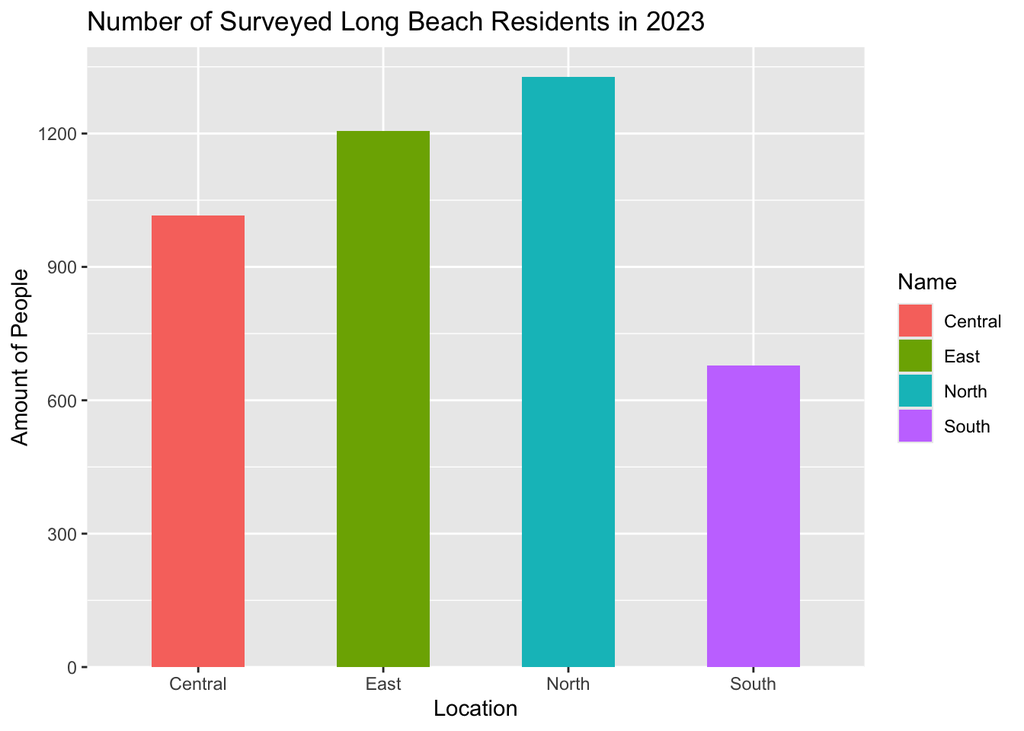

```r
#number of surveyed individuals per lb neighborhood in 2023
total_data <- data.frame(Name = c("East", "South", "North", "Central"), Value = c(east_total, south_total, north_total, central_total))

ggplot(total_data, aes(x = Name, y = Value, fill = Name)) + geom_col(stat = "identity", width = 0.5) + scale_y_continuous(expand = expansion(mult = c(0, 0.05)), breaks = seq(0, 1500, by = 300)) + xlab("Location") + ggtitle("Number of Surveyed Long Beach Residents in 2023") + ylab("Amount of People")
```

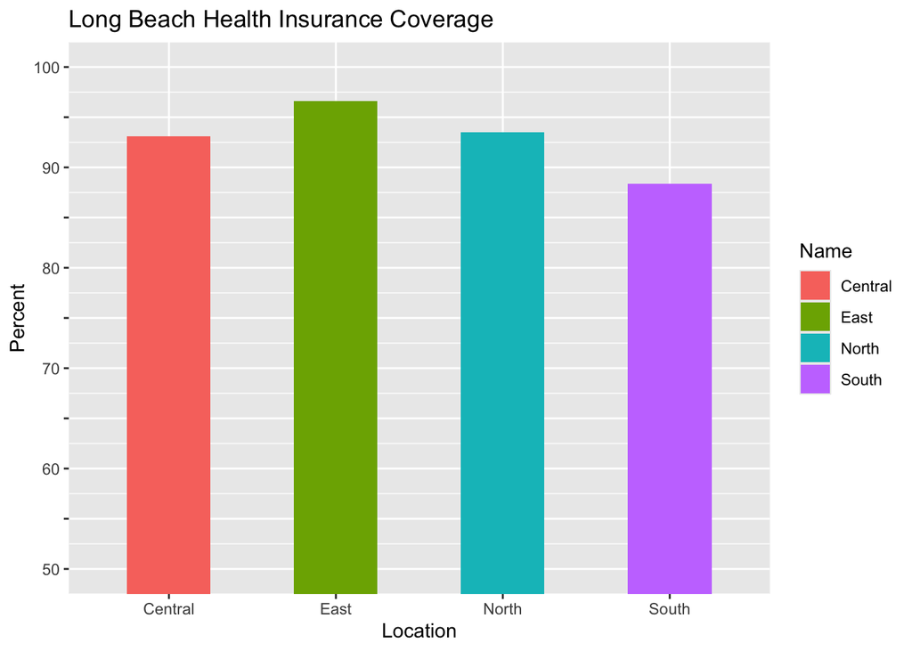

```r
#percentage has health insurance per neighborhood
health_data <- data.frame(Name = c("East", "South", "North", "Central"), Value = c(health_e, health_s, health_n, health_c))

ggplot(health_data, aes(x = Name, y = Value, fill = Name)) + geom_col(stat = "identity", width = 0.5) + coord_cartesian(ylim = c(50, 100)) + xlab("Location") + ggtitle("Long Beach Health Insurance Coverage") + scale_y_continuous(breaks = seq(50, 100, by = 5), labels = c("50", "", "60", "", "70", "", "80", "", "90", "", "100")) + ylab("Percent")
```

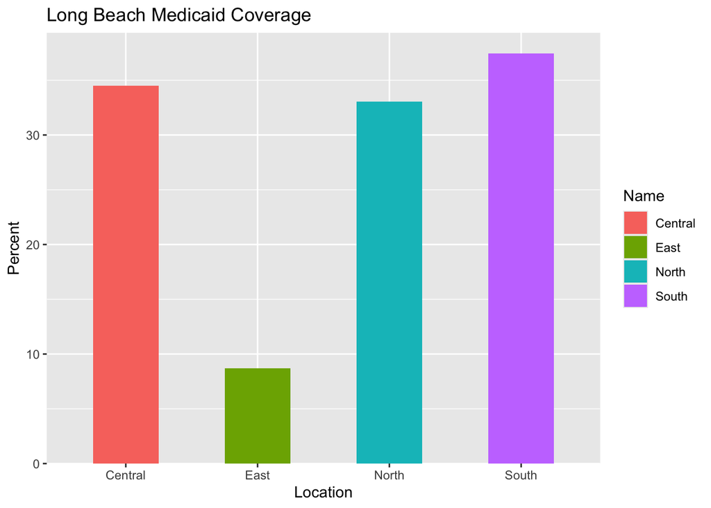

```r
#percentage has medicaid per neighborhood
aid_data <- data.frame(Name = c("East", "South", "North", "Central"), Value = c(med_e, med_s, med_n, med_c))

ggplot(aid_data, aes(x = Name, y = Value, fill = Name)) + geom_col(stat = "identity", width = 0.5) + scale_y_continuous(expand = expansion(mult = c(0, 0.05))) + xlab("Location") + ggtitle("Long Beach Medicaid Coverage") + ylab("Percent")
```

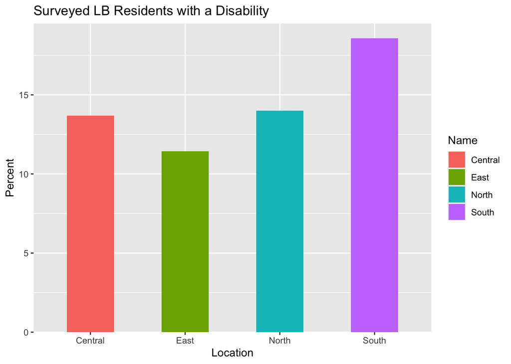

```r
#percentage has disability per neighborhood
able_data <- data.frame(Name = c("East", "South", "North", "Central"), Value = c(able_e, able_s, able_n, able_c))

ggplot(able_data, aes(x = Name, y = Value, fill = Name)) + geom_col(stat = "identity", width = 0.5) + scale_y_continuous(expand = expansion(mult = c(0, 0.05))) + xlab("Location") + ylab("Percent") + ggtitle("Surveyed LB Residents with a Disability")
```

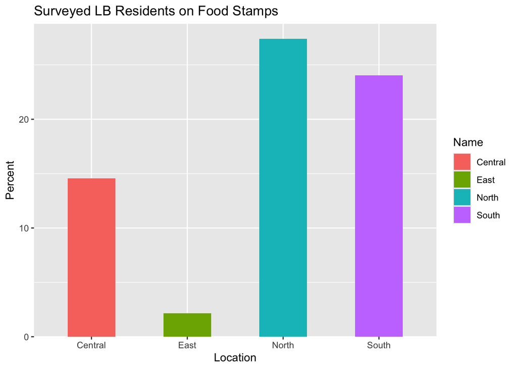

```r
#percent is on food stamps per neighborhood
food_data <- data.frame(Name = c("East", "South", "North", "Central"), Value = c(food_e, food_s, food_n, food_c))

ggplot(food_data, aes(x = Name, y = Value, fill = Name)) + geom_col(stat = "identity", width = 0.5) + scale_y_continuous(expand = expansion(mult = c(0, 0.05))) + xlab("Location") + ylab("Percent") + ggtitle("Surveyed LB Residents on Food Stamps")
```

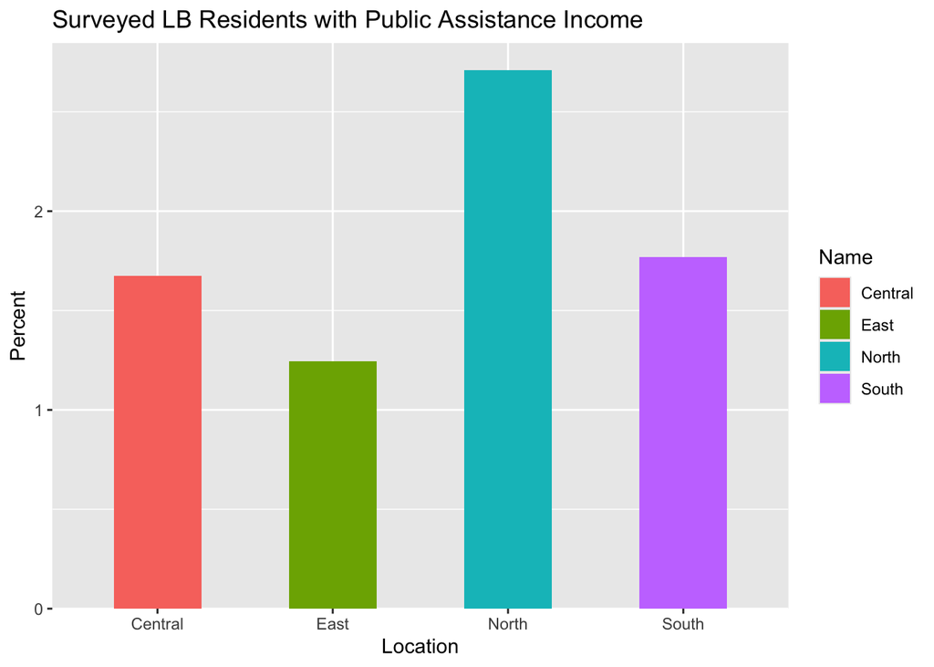

```r
#percentage people have public assistance income in long beach per neighborhood
pub_data <- data.frame(Name = c("East", "South", "North", "Central"), Value = c(avg_pub_e, avg_pub_s, avg_pub_n, avg_pub_c))

ggplot(pub_data, aes(x = Name, y = Value, fill = Name)) + geom_col(stat = "identity", width = 0.5) + scale_y_continuous(expand = expansion(mult = c(0, 0.05))) + xlab("Location") + ylab("Percent") + ggtitle("Surveyed LB Residents with Public Assistance Income")
```

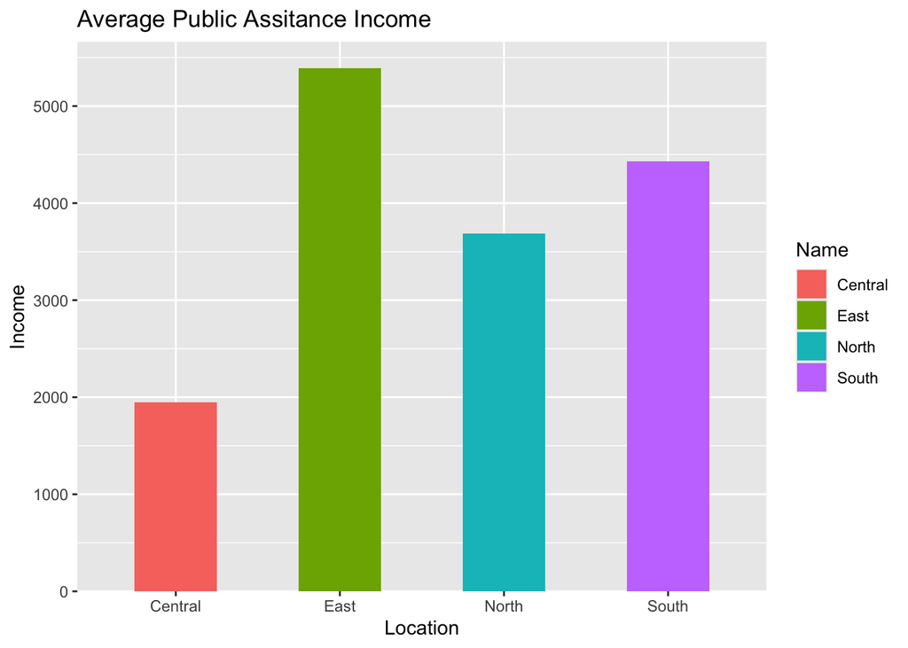

```r
#average public assistance income per neighborhood
pub_avg_data <- data.frame(Name = c("East", "South", "North", "Central"), Value = c(public_e, public_s, public_n, public_c))

ggplot(pub_avg_data, aes(x = Name, y = Value, fill = Name)) + geom_col(stat = "identity", width = 0.5) + scale_y_continuous(expand = expansion(mult = c(0, 0.05))) + xlab("Location") + ylab("Income") + ggtitle("Average Public Assitance Income")
```

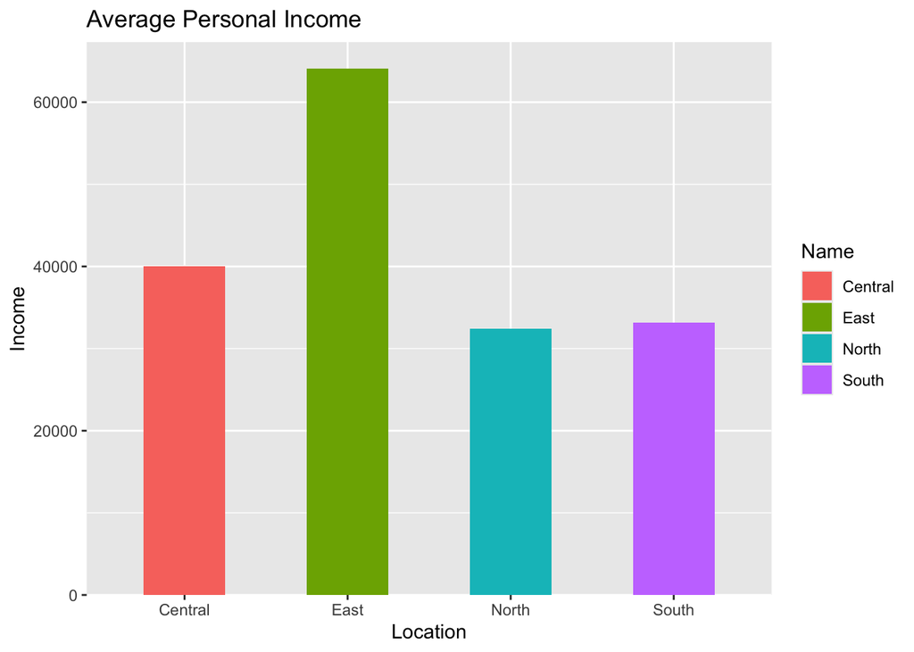

```r
#average personal income per neighborhood
money_data <- data.frame(Name = c("East", "South", "North", "Central"), Value = c(money_e, money_s, money_n, money_c))

ggplot(money_data, aes(x = Name, y = Value, fill = Name)) + geom_col(stat = "identity", width = 0.5) + scale_y_continuous(expand = expansion(mult = c(0, 0.05))) + xlab("Location") + ylab("Income") + ggtitle("Average Personal Income")
```

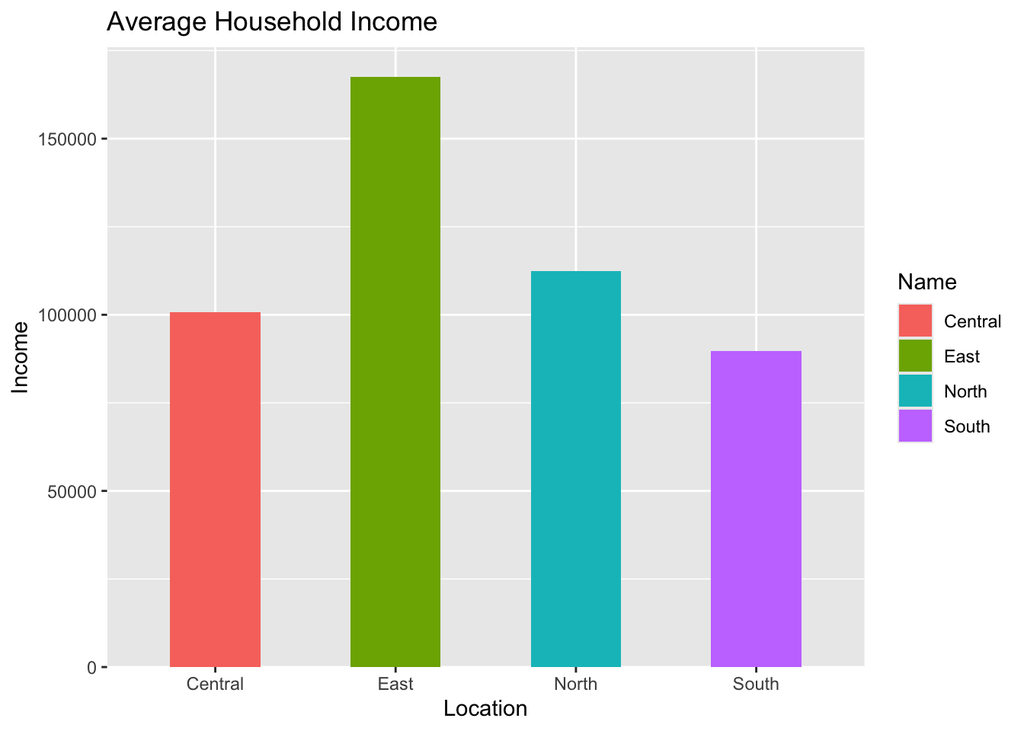

```r
#average household income per neighborhood
house_data <- data.frame(Name = c("East", "South", "North", "Central"), Value = c(house_e, house_s, house_n, house_c))

ggplot(house_data, aes(x = Name, y = Value, fill = Name)) + geom_col(stat = "identity", width = 0.5) + scale_y_continuous(expand = expansion(mult = c(0, 0.05))) + xlab("Location") + ylab("Income") + ggtitle("Average Household Income")
```

# Please include additional sections as desired.

[figure not shown]

```r
#tried a bar plot for min, mean, max of household income
east_min <- subdat |> filter(location == "East Long Beach") |> pull(household_income) |> min()
east_max <- subdat |> filter(location == "East Long Beach") |> pull(household_income) |> max()
south_min <- subdat |> filter(location == "South Long Beach") |> pull(household_income) |> min()
south_max <- subdat |> filter(location == "South Long Beach") |> pull(household_income) |> max()
north_min <- subdat |> filter(location == "North Long Beach") |> pull(household_income) |> min()
north_max <- subdat |> filter(location == "North Long Beach") |> pull(household_income) |> max()
cen_min <- subdat |> filter(location == "Central Long Beach") |> pull(household_income) |> min()
cen_max <- subdat |> filter(location == "Central Long Beach") |> pull(household_income) |> max()


plot_data <- data.frame(Name = c("East", "South", "North", "Central"), Value = c(east_min, east_max, house_e, south_min, south_max, house_s, north_min, north_max, house_n, cen_min, cen_max, house_c ))
ggplot(data = plot_data, aes(x = Name, y = Value)) + geom_point(aes(colour = factor(Name))) + scale_y_continuous(breaks = seq(-70000, 1000000, by = 50000), labels = c("-70,000", "", "30,000", "", "130,000", "", "230,000", "", "330,000", "", "430,000", "", "530,000", "", "630,000", "", "730,000", "", "830,000", "", "930,000", "")) + xlab("Location") + ylab("Income") + ggtitle("Min, Mean, and Max Household Incomes")
```

# Versions

Render your document to an html or pdf using the “Knit” button.